# GTEx Pilot: mRNA–mRNA Correlation in Context (Tissues)

Amir (building on Kevin R. Coombes’ framework)

Original: 2026-01-05; Latest Run: 2026-01-05

# Summary

We want to test whether “correlation in context” is cancer-specific. GTEx provides a non-cancer setting with strong biological context: tissue type.

In this pilot we: 1) load GTEx mRNA expression (Xena-derived) and tissue labels (parsed from sample IDs), 2) quantify heterogeneity of mRNA–mRNA correlations across tissues using Cochran’s Q / I², 3) estimate how often global correlation disagrees with the tissue-majority sign, and 4) produce a canonical Simpson-style visualization for one mRNA–mRNA pair.

To keep this fast, we work on the top variable genes and sample a manageable number of gene pairs.

# Load GTEx data

Rationale: load the saved GTEx object and inspect its shape. The file uses Xena-style sample IDs that embed a four-digit tissue code (e.g., `... .0011. ...`).

```r
f1 <- "/home/amir/datasets/mirTCGA/xena-gtex.Rda"
f2 <- "/home/amir/datasets/mirTCGA/clean/xena-gtex.Rda"
if (file.exists(f1)) {
  load(f1)
} else if (file.exists(f2)) {
  load(f2)
} else {
  stop("Cannot find xena-gtex.Rda at ", f1, " or ", f2)
}
stopifnot(is.list(gtex), "mrna" %in% names(gtex))

X <- as.matrix(gtex$mrna)  # genes x samples, values appear to be log2(TPM + 0.001)
dim(X)
```

```
## [1] 19069  7792
```

We have 19k genes across ~7.8k samples. Next we derive tissue codes from the sample IDs.

# Tissue labels

Rationale: parse the 4-digit tissue code from Xena GTEx sample IDs; use it as a “context” label.

```r
parse_tissue_code <- function(ids) {
  out <- sub("^GTEX\\.[^.]+\\.([0-9]{4})\\..*$", "\\1", ids)
  out[out == ids] <- NA_character_
  out
}

tissue_code <- parse_tissue_code(colnames(X))
stopifnot(all(!is.na(tissue_code)))

tab <- sort(table(tissue_code), decreasing = TRUE)
head(tab, 20)
```

```
## tissue_code
## 0011 0326 0226 0426 0526 0126 0626 0826 0008 0726 0926 1026 1326 1126 1226 1426 1626 1526 1726
##  928  329  322  313  307  305  281  261  256  252  250  239  231  221  213  208  201  200  200
## 0006
##  181
```

```r
length(tab)
```

```
## [1] 52
```

We see dozens of tissues with varying sample sizes. For stable correlation estimates, we restrict to tissues with reasonably large sample sizes and then keep the top set.

Rationale: pick the largest tissues to keep computations tractable.

```r
min_n <- 150
keep_tissues <- names(tab)[tab >= min_n]
# Keep at most 20 tissues for a first pilot.
keep_tissues <- keep_tissues[1:min(20, length(keep_tissues))]
keep_tissues
```

```
##  [1] "0011" "0326" "0226" "0426" "0526" "0126" "0626" "0826" "0008" "0726" "0926" "1026" "1326"
## [14] "1126" "1226" "1426" "1626" "1526" "1726" "0006"
```

```r
tab[keep_tissues]
```

```
## tissue_code
## 0011 0326 0226 0426 0526 0126 0626 0826 0008 0726 0926 1026 1326 1126 1226 1426 1626 1526 1726
##  928  329  322  313  307  305  281  261  256  252  250  239  231  221  213  208  201  200  200
## 0006
##  181
```

Now we choose a subset of genes for an efficient mRNA–mRNA scan.

# Gene subset and pair sampling

Rationale: mRNA–mRNA is extremely high-dimensional; start with the most variable genes.

```r
G <- 1500
geneVar <- apply(X, 1, var)
genes <- names(sort(geneVar, decreasing = TRUE))[1:G]
length(genes)
```

```
## [1] 1500
```

We next sample gene pairs from this subset. We intentionally sample many pairs so we can estimate rates and distributions without computing all $\approx 1.1$ million pairs.

Rationale: sample P unique gene pairs (i < j).

```r
set.seed(1)
P <- 200000

sample_pairs <- function(G, P) {
  i <- sample.int(G, size = 2 * P, replace = TRUE)
  j <- sample.int(G, size = 2 * P, replace = TRUE)
  ok <- i != j
  i <- i[ok]; j <- j[ok]
  a <- pmin(i, j); b <- pmax(i, j)
  key <- paste(a, b, sep = "_")
  u <- !duplicated(key)
  a <- a[u]; b <- b[u]
  if (length(a) < P) stop("Not enough unique pairs sampled.")
  list(i = a[1:P], j = b[1:P])
}

pairs <- sample_pairs(G, P)
str(pairs)
```

```
## List of 2
##  $ i: int [1:200000] 494 660 129 930 471 299 270 753 894 597 ...
##  $ j: int [1:200000] 1017 679 528 1308 1307 492 565 1211 1331 599 ...
```

Now we compute global correlations and then tissue-specific correlations for these sampled pairs.

# Global correlations

Rationale: compute the full correlation matrix once for the gene subset, then extract sampled pairs.

```r
Xsub <- X[genes, , drop = FALSE]
cor_global <- cor(t(Xsub))

r_global <- cor_global[cbind(pairs$i, pairs$j)]
summary(r_global)
```

```
##     Min.  1st Qu.   Median     Mean  3rd Qu.     Max.
## -0.60477 -0.03722  0.07356  0.10798  0.22640  0.93763
```

We now compute within-tissue correlation for the same sampled pairs.

# Tissue-specific correlations (sampled pairs)

Rationale: for each tissue, compute the correlation matrix for the gene subset and extract sampled pairs.

```r
R <- matrix(NA_real_, nrow = P, ncol = length(keep_tissues),
            dimnames = list(NULL, keep_tissues))
N <- setNames(integer(length(keep_tissues)), keep_tissues)

for (tt in keep_tissues) {
  idx <- which(tissue_code == tt)
  N[tt] <- length(idx)
  Xtt <- Xsub[, idx, drop = FALSE]
  Ct <- suppressWarnings(cor(t(Xtt)))
  R[, tt] <- Ct[cbind(pairs$i, pairs$j)]
}

summary(as.vector(R))
```

```
##     Min.  1st Qu.   Median     Mean  3rd Qu.     Max.     NA's
## -0.73298 -0.02530  0.07073  0.09134  0.18788  0.97644      251
```

Now we can quantify two things: (1) how often global sign disagrees with the tissue-majority sign, and (2) how heterogeneous correlations are across tissues (Q/I²).

# Reversal rate and heterogeneity (Q / I²)

Rationale: compute sign-majority across tissues and Cochran’s Q/I² on Fisher Z.

```r
fz <- function(r) 0.5 * log((1 + r)/(1 - r))

valid <- is.finite(R) & abs(R) < 1
k <- rowSums(valid)

sgn_majority <- rep(NA_integer_, P)
sgn_majority[k > 0] <- sign(rowSums(valid & R > 0) - rowSums(valid & R < 0))[k > 0]

reversal <- k > 0 & sign(r_global) != sgn_majority & sign(r_global) != 0 & sgn_majority != 0

rate_all <- mean(reversal, na.rm = TRUE)
rate_strong <- mean(reversal[abs(r_global) >= 0.2], na.rm = TRUE)
c(reversal_all = rate_all, reversal_if_abs_global_ge_0p2 = rate_strong)
```

```
##                  reversal_all reversal_if_abs_global_ge_0p2
##                    0.17416000                    0.04940748
```

```r
# Q / I2
z <- fz(pmin(pmax(R, -0.999999), 0.999999))
W <- matrix(rep((N - 3), each = P), nrow = P)
W[!valid] <- 0
z[!valid] <- 0

sum_w <- rowSums(W)
z_bar <- rowSums(W * z)/pmax(sum_w, 1e-12)
Q <- rowSums(W * (z - z_bar)^2, na.rm = TRUE)
df <- pmax(k - 1, 0)
I2 <- rep(NA_real_, P)
ok <- df >= 1 & is.finite(Q)
I2[ok] <- pmax(0, (Q[ok] - df[ok])/pmax(Q[ok], 1e-12))
summary(I2)
```

```
##    Min. 1st Qu.  Median    Mean 3rd Qu.    Max.
##  0.0000  0.5104  0.7162  0.6498  0.8492  0.9934
```

If reversal and I² are substantial, that is strong evidence that “correlation in context” is not specific to cancer.

# Tissue-mean residualization (Simpson diagnostic)

Rationale: global correlations can be driven by between-tissue mean differences. We remove tissue means per gene and recompute correlation. This is the GTEx analog of `407`.

```r
Xres <- Xsub
for (tt in keep_tissues) {
  idx <- which(tissue_code == tt)
  Xres[, idx] <- sweep(Xsub[, idx, drop = FALSE], 1,
                       rowMeans(Xsub[, idx, drop = FALSE]), "-")
}
cor_resid <- cor(t(Xres))
r_resid <- cor_resid[cbind(pairs$i, pairs$j)]

flip_resid <- sign(r_global) != sign(r_resid) & r_global != 0 & r_resid != 0
c(
  sign_flip_global_vs_resid = mean(flip_resid, na.rm = TRUE),
  sign_flip_if_abs_global_ge_0p2 = mean(flip_resid[abs(r_global) >= 0.2], na.rm = TRUE)
)
```

```
##      sign_flip_global_vs_resid sign_flip_if_abs_global_ge_0p2
##                     0.27245500                     0.07231221
```

If these flip rates are non-trivial, it suggests a practical recommendation: when samples span multiple tissues, always check residualized correlation.

Rationale: visualize global vs residualized correlations for the sampled pairs.

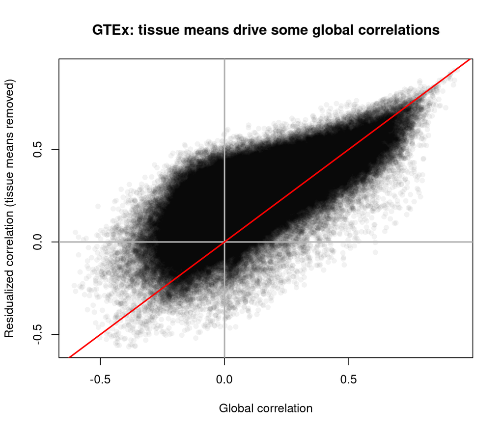

Figure 2 : Global vs residualized GTEx mRNA–mRNA correlations (sampled pairs).

```r
set.seed(1)
ok2 <- is.finite(r_global) & is.finite(r_resid)
ix <- which(ok2)
if (length(ix) > 200000) ix <- sample(ix, 200000)

plot(r_global[ix], r_resid[ix],
     pch = 16, col = rgb(0, 0, 0, 0.05),
     xlab = "Global correlation",
     ylab = "Residualized correlation (tissue means removed)",
     main = "GTEx: tissue means drive some global correlations")
abline(h = 0, v = 0, lwd = 2, col = "grey70")
abline(a = 0, b = 1, lwd = 2, col = "red")
```

# Choose a Simpson-style example pair

Rationale: find a pair with a strong global correlation but opposite tissue-majority sign, and high heterogeneity.

```r
score <- rep(-Inf, P)
score[reversal & is.finite(I2)] <- abs(r_global[reversal & is.finite(I2)]) * I2[reversal & is.finite(I2)]
best <- which.max(score)

g1 <- genes[pairs$i[best]]
g2 <- genes[pairs$j[best]]

list(gene1 = g1, gene2 = g2, global_r = r_global[best], I2 = I2[best])
```

```
## $gene1
## [1] "ENSG00000197576.13"
##
## $gene2
## [1] "ENSG00000089169.14"
##
## $global_r
## [1] -0.5820411
##
## $I2
## [1] 0.873667
```

We now build a canonical Simpson-style visualization for this pair.

# Canonical plot (4 panels)

Rationale: mimic the Simpson panel figure: global scatter, within-tissue correlations, tissue means, and a filtered Simpson overlay (top K tissues by |r| for visibility).

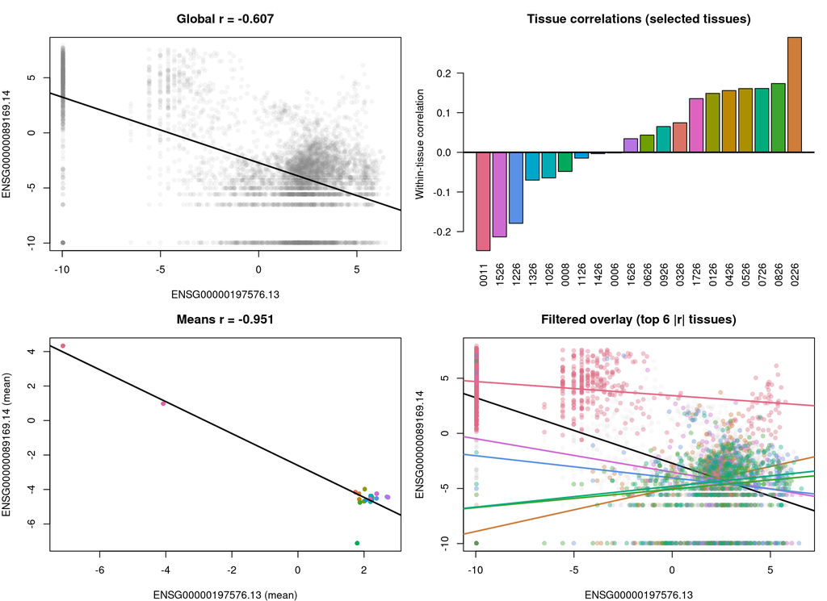

Figure 1 : A Simpson-style mRNA–mRNA example in GTEx (tissue context).

```r
K <- 6

x <- as.numeric(X[g1, ])
y <- as.numeric(X[g2, ])
tt <- factor(tissue_code, levels = keep_tissues)
in_keep <- !is.na(tt)
x <- x[in_keep]; y <- y[in_keep]; tt <- droplevels(tt[in_keep])

# Tissue colors
cols <- grDevices::hcl.colors(nlevels(tt), "Dark 3")
names(cols) <- levels(tt)

r_tissue <- R[best, ]
ord <- order(r_tissue, na.last = NA)
topK <- names(sort(abs(r_tissue), decreasing = TRUE))[1:min(K, sum(!is.na(r_tissue)))]

opar <- par(mfrow = c(2, 2), mar = c(4, 4, 3, 1))

plot(x, y, pch = 16, col = rgb(0.5, 0.5, 0.5, 0.08),
     xlab = g1, ylab = g2,
     main = sprintf("Global r = %.3f", cor(x, y)))
abline(lm(y ~ x), lwd = 2)

barplot(r_tissue[ord], las = 2, col = cols[names(r_tissue)[ord]],
        ylab = "Within-tissue correlation",
        main = "Tissue correlations (selected tissues)")
abline(h = 0, lwd = 2)
abline(h = cor(x, y), lwd = 2)

xm <- tapply(x, tt, mean)
ym <- tapply(y, tt, mean)
plot(as.numeric(xm), as.numeric(ym), pch = 16, col = cols[names(xm)],
     xlab = paste(g1, "(mean)"), ylab = paste(g2, "(mean)"),
     main = sprintf("Means r = %.3f", cor(as.numeric(xm), as.numeric(ym))))
abline(lm(as.numeric(ym) ~ as.numeric(xm)), lwd = 2)

plot(x, y, pch = 16, col = rgb(0.6, 0.6, 0.6, 0.06),
     xlab = g1, ylab = g2,
     main = sprintf("Filtered overlay (top %d |r| tissues)", length(topK)))
abline(lm(y ~ x), lwd = 2)
for (t0 in topK) {
  idx <- tt == t0
  points(x[idx], y[idx], pch = 16, col = rgb(col2rgb(cols[t0])[1]/255, col2rgb(cols[t0])[2]/255, col2rgb(cols[t0])[3]/255, 0.35))
  abline(lm(y[idx] ~ x[idx]), col = cols[t0], lwd = 2)
}
```

```r
par(opar)
```

This is the non-cancer analog of the TCGA Simpson plot: a global association that is in tension with the within-tissue pattern.

# Next steps